# Global synthesis of leaf area index observations: implications for ecological and remote sensing studies - Asner - 2003 - Global Ecology and Biogeography - Wiley Online Library

- Skip to Article Content
- Skip to Article Information

[Login / Register](https://onlinelibrary.wiley.com/action/showLogin?uri=%2Fdoi%2Ffull%2F10.1046%2Fj.1466-822X.2003.00026.x&aria-label=Log+in+or+Register)

[Global Ecology and Biogeography](https://onlinelibrary.wiley.com/journal/14668238)

[Volume 12, Issue 3](https://onlinelibrary.wiley.com/toc/14668238/2003/12/3) p. 191-205

Full Access

# Global synthesis of leaf area index observations: implications for ecological and remote sensing studies

[Gregory P. Asner](https://onlinelibrary.wiley.com/action/doSearch?ContribAuthorStored=Asner%2C+Gregory+P)

Corresponding author.

[Jonathan M. O. Scurlock](https://onlinelibrary.wiley.com/action/doSearch?ContribAuthorStored=Scurlock%2C+Jonathan+M+O)

[Jeffrey A. Hicke](https://onlinelibrary.wiley.com/action/doSearch?ContribAuthorStored=A.+Hicke%2C+Jeffrey)

First published: 11 April 2003

https://doi.org/10.1046/j.1466-822X.2003.00026.x

Citations: 430

## ABSTRACT

**Aim** We present the first global synthesis of plant canopy leaf area index (LAI) measurements from more than 1000 published estimates representing ∼400 unique field sites. LAI is a key variable for regional and global models of biosphere‐atmosphere exchanges of energy, carbon dioxide, water vapour, and other materials.

**Location** The location is global, geographically distributed.

**Main conclusions** Applications of the LAI database span a wide range of ecological, biogeochemical, physical, and climate research areas. The data provide input to terrestrial ecosystem and land‐surface models, for evaluation of global remote sensing products, for comparisons to field studies, and other applications. Example uses of the database for global plant productivity, fractional energy absorption, and remote sensing studies are highlighted.

## INTRODUCTION

The plant canopy is a locus of physical and biogeochemical processes in an ecosystem. The functional and structural attributes of plant canopies are affected by microclimatic conditions, nutrient dynamics, herbivore activities, and many other factors. The amount of foliage contained in plant canopies is one basic ecological characteristic indicating the integrated effect of these factors. In turn, canopy leaf area serves as the dominant control over primary production (photosynthesis), transpiration, energy exchange, and other physiological attributes pertinent to a range of ecosystem processes. Subsequently, canopy leaf area is often treated as a core element of ecological field and modelling studies (e.g. Sellers *et al*., 1988; Sellers, 1997; Bondeau *et al*., 1999).

Leaf area index (LAI) is a measure of canopy foliage content commonly employed in studies of vegetation and ecosystems. LAI is broadly defined as the amount of leaf area (m<sup>2</sup>) in a canopy per unit ground area (m<sup>2</sup>). Because it is a dimensionless quantity, LAI can be measured, analysed and modelled across a range of spatial scales, from individual tree crowns or clusters to whole regions or continents. As a result, LAI has become a central and basic descriptor of vegetation condition in a wide variety of physiological, climatological, and biogeochemical studies (Asner *et al*., 1998a). LAI is a key vegetation characteristic needed by the global change research community (e.g. Running & Coughlan, 1988; Sellers & Schimel, 1993). For example, LAI is required for scaling between leaf and canopy measurements of water vapour and CO<sub>2</sub> conductance and flux, and for estimates of these variables across the global biosphere–atmosphere interface (McWilliam *et al*., 1993).

Despite the widely recognized importance of LAI across such a broad range of physical and ecological research, and although there is an abundance of individual plot and stand‐based LAI studies, there are few comprehensive reviews of LAI data in the literature. Waring (1983) discussed LAI of forests as an index of growth and canopy light competition, but did not tabulate data from previous studies. Schulze (1982) analysed leaf area and canopy light interception in a review of 62 LAI estimates from 12 biomes. Asner (1998) studied canopy reflectance variation using a compilation of 29 LAI estimates from 20 vegetation types. Gower *et al*. (1999) reviewed LAI estimation techniques, but again did not summarize many previous data. In general, the highest values reported previously for LAI are for coniferous canopies, in some cases LAI > 15, although this is partly a function of how LAI is defined and measured (see next section). Beadle (1993) reported observed LAI maxima from 6 to 8 in deciduous forest and 2–4 for annual crops. Schulze (1982) suggested that typical leaf area index values for most biomes (apart from desert and tundra) ranged from about 3–19, the highest values being reported for boreal coniferous forests. Despite the reports provided by these and other authors, no studies have provided the comprehensive data compilation and synthesis needed for broad determinations of the range and properties of LAI values by biome, either globally or through time.

In this paper we present a literature review, database and synthesis of 1008 LAI measurements collected from 15 global biomes. This paper serves as an extension to a technical report developed by us for the Oak Ridge National Laboratory (Scurlock *et al*., 2001), with additional analyses pertinent to ecological and remote sensing applications of the database. The specific goals of this paper are: (1) to present our LAI compilation to a broad global ecological research audience to maximize the exposure and availability of the database; (2) to determine the differences in LAI by biome and over different publication periods; (3) to highlight weaknesses in the ecological and geographical coverage of LAI measurements on a global basis; and (4) to demonstrate the value of the database for studying linkages between canopy structure and function.

## METHODS

### Definition of LAI

LAI may be described most simply as:

LAI = *s*/*G*

(1)

where *s* is the functional (green) leaf area of the canopy per ground area *G* (terminology after Beadle, 1993). The *s* term is most commonly measured as the projected area; that is, after placing a sampled leaf on a horizontal surface. However, LAI may be more precisely defined in a number of different ways, and this bears on the results synthesized in this paper. For example, leaf area may be measured as the total surface area of leaves in a canopy. This is equal to 2 *s* for flat leaves and greater than 2 *s* for needles, succulent leaves and photosynthetic stems. This complicates comparisons between LAI measurements collected using different methodologies (Chen & Black, 1992).

Barclay (1998) indicated that at least five common measures of LAI exist, which partly reflect the different purposes for which LAI is determined (e.g. vegetation growth, physiological activity, light attenuation). The four most common of these are defined as:

- 1

  Total LAI based on the total outside area of the leaves, taking leaf shape into account, per unit area of horizontal land below the canopy;
- 2

  One‐sided LAI, as half the total LAI, even if the two sides of the leaves are not symmetrical;
- 3

  Horizontally projected LAI as the area of ‘shadow’ that would be cast by each leaf in the canopy with a light source at infinite distance and perpendicular to it, summed up for all leaves in the canopy;
- 4

  Inclined projected LAI, or ‘silhouette’ LAI, representing the projected area of leaves while accounting for leaf inclinations. An additional fifth definition, according to Barclay (1998), is a variation on this approach, counting overlapping leaf areas only once.

Most published values of LAI utilize definition (2) or definition (3), with an increasing number of definition (4) in the recent literature (Barclay, 1998). Definition (1) is rarely employed. Definition (2) suffers from the problem that the meaning of ‘one‐sided’ is unclear for coniferous needles, highly clumped foliage or rolled leaves. Chen & Black (1992) suggested that the LAI of nonflat leaves should be defined as half the total intercepting area per unit ground area, and that definition (3) should be abandoned. LAI according to definition (2) may exceed LAI according to definition (3) by a factor ranging from 1.28 (hemi‐circular cylinders representing conifer needles), through 1.57 (representing cylindrical green branches) to 2.0 (spheres or square bars representing highly clumped shoots and some spruce needles) (Chen & Cihlar, 1996). Regrettably, many individual reports of LAI in the literature fail to provide any details of the LAI definition assumed, and a significant fraction do not describe the methodology used.

### Methods of determining LAI

Methodologies for ground‐based estimation of LAI include:

- (a)

  Destructive harvesting and direct determination of one‐sided leaf area, using squared grid paper, weighing of paper replicates, or an optically based automatic area measurement system;
- (b)

  Collection and weighing of total leaf litterfall, converted to leaf area by determining specific leaf area (leaf area/leaf mass) of foliar subsamples;
- (c)

  Allometry (based on simple physical dimensions such as stem diameter at breast height), using species‐specific or stand‐specific relationships based on detailed destructive measurement of a subsample of leaves, branches or whole individuals;
- (d)

  Indirect contact methods such as plumb lines or inclined point quadrats;
- (e)

  Indirect noncontact methods such as the Decagon Ceptometer (Decagon Devices, Inc. Pullman, Washington, U.S.A.), the LICOR LAI‐2000 (Li‐Cor, Inc., Lincoln, Nebraska, U.S.A.), or analysis of hemispheric photographs.

Methodologies (a) and (b) are commonly used in conjunction with definition (2) of LAI, while methodologies (d) and (e) are used with definitions (3) and (4), respectively. Methodology (c) may be used with any of the LAI definitions, including definition (1), depending upon the details of the calibration of the allometric equations. Whereas all of these methodologies may be used for forest canopies, (a) tends to be the most common for grasslands and crops, and (d) or (c) for irregularly shaped canopies such as shrublands. In many cases, the choice of methodology is a matter of ease of use in a particular field situation.

The user of LAI data should note that almost all of these methodologies are subject to limitations such as sampling error (small plots, etc.) for direct determination, and nonrandom leaf distribution and inclination in the case of the indirect methods. For example, specific leaf area in an experimental stand of sweetgum (*Liquidambar styraciflua*) may vary by a factor of more than two between sun and shade leaves, making it difficult to utilize an annual average value for the determination of LAI by methodology (b) above (Norby *et al*., 2001). The wide range of leaf turnover times, from less than 12 months to about six years, may also present problems for this methodology. Some knowledge of the dynamics of leaf area production and abscission is really required to estimate LAI. Leaf spatial distribution, leaf angle distribution and the contribution of nonphotosynthetic tissue to light attenuation are all complicating factors in methodology (e), the optical determination of LAI, which was originally developed for crop canopies (Chen, 1996). Strictly speaking, optical methods estimate ‘plant area index’ (PAI), which includes projected stem area as well as leaves. For certain types of vegetation, instruments such as the LAI‐2000 have also been found to under‐estimate LAI systematically compared with other methodologies (Deblonde *et al*., 1994; Kucharik *et al*., 1998; Gower *et al*., 1999).

The seasonal timing of LAI measurements is also an important consideration. In deciduous canopies, reported values will vary substantially by sampling time relative to maximum seasonal LAI. Even for evergreen canopies, there may be an important difference between annual maximum LAI and the average LAI during the growing season. LAI phenology tends to be overlooked in much of the literature.

### Data compilation

The process of compiling the database involved identifying sites and sources of data, acquiring the data, meta‐data and other documentation, performing quality assessment checks, and reformatting the data into a consistent and comparable form. The data compiled for the LAI database represented mostly natural ecosystems; however, some data from crops, pastures and tree plantations were included for comparison. As far as possible, the minimum criteria for inclusion of data in this compilation were the following:

- •

  A geographical or place‐name reference to the site of measurement (data related to vegetation types only were not considered);
- •

  At least some ancillary data on vegetation type, stand age, etc. and preferably other physiological parameters such as above‐ground NPP;
- •

  A citation to the source of the data.

Where the geographical coordinates of the experimental site were not included in the original literature, coordinates were selected from national or regional maps, based upon site descriptions. A variety of published maps, road atlases, and online maps were used for this purpose.

The initial data compilation yielded 1008 unique records from 339 known field sites, with an additional 69 records for which coordinates could not be estimated (∼400 locations). Each record represented a unique value reported for a particular vegetation type, treatment or vegetation condition (maximum LAI, minimum LAI) at an individual study site. Records were matched to a bibliography of over 300 original literature references, which can be accessed in the technical memorandum provided by Scurlock *et al*. (2001).

Criteria for maximizing data consistency included the use of common systems of names, units, etc., including names of countries and a biome assignment to one of 15 classes (Appendix 1). These classes are based upon those developed for the Ecosystem Model‐Data Intercomparison workshops under the auspices of the Global Primary Production Data Initiative (Scurlock *et al*., 1999; Olson *et al*., 2001). They represent a compromise between biome and land‐cover classes that are meaningful to ecologists, ecosystem modellers and users of satellite remote sensing data. Geographical coordinates were converted to decimal degrees (ddd.dd) and mapped using Geographical Information System software (ArcGIS, ESRI, Inc.) to check for erroneous coordinates located in water bodies or other unlikely locations.

A common statistical outlier analysis was used to determine LAI data values that were unlikely to be accurately reported, either in measurement or in recording of the data. The interquartile range (IQR) approach is a nonparametric analytical method that identifies outliers via a detailed statistical determination of a data distribution (Sokal & Rohlf, 1981). The data were first ranked from lowest numerical value to highest, and the median and quartiles of the data set were determined. Statistical outliers were then defined as those data values that lie beyond an ‘inner fence’, which is defined by:

where *F*<sub>1</sub> and *F*<sub>3</sub> are the first and third quartiles and IQR = *F*<sub>3</sub>–*F*<sub>1</sub>. Although we provide the statistical summary of the LAI database with outliers removed, the example uses of the data presented in the remainder of the paper employed the LAI measurements without removal of outliers.

## RESULTS AND DISCUSSION

### LAI by biome

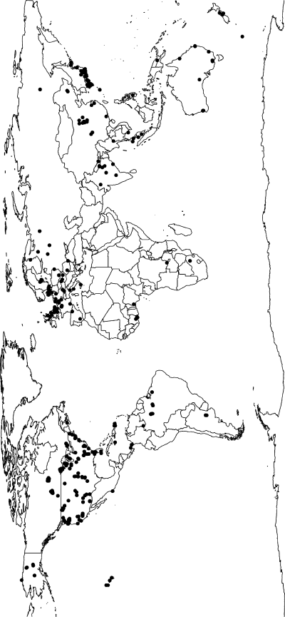

**Figure 1**

Open in figure viewer[PowerPoint](https://onlinelibrary.wiley.com/action/downloadFigures?id=f1&doi=10.1046%2Fj.1466-822X.2003.00026.x)

Global distribution of field sites in the LAI database.

Table 1. Frequency of leaf area index estimates for countries with more than 10 records

| Country | Frequency | % |
| --- | --- | --- |
| Australia | 43 | 4.3 |
| Brazil | 21 | 2.1 |
| Canada | 58 | 5.8 |
| China | 28 | 2.8 |
| France | 17 | 1.7 |
| India | 32 | 3.2 |
| Japan | 153 | 15.2 |
| New Zealand | 14 | 1.4 |
| Nepal | 11 | 1.1 |
| Puerto Rico | 13 | 1.3 |
| Russia | 22 | 2.2 |
| Sweden | 15 | 1.5 |
| UK | 63 | 6.3 |
| USA | 417 | 41.4 |
| Venezuela | 10 | 1.0 |
| Others | 91 | 9.0 |

Table 2. Statistical distribution of leaf area index by biome for the original data compilation and after removal of statistical outliers using Inter‐Quartile Range (IQR) analysis (see Appendix 2 for key to acronyms)

| Biome | Original data Observations | Original data Mean | Original data Standard deviation | Original data Min | Original data Max | Data after IQR analysis Outliers Removed | Data after IQR analysis Mean | Data after IQR analysis Standard deviation | Data after IQR analysis Min | Data after IQR analysis Max |
| --- | --- | --- | --- | --- | --- | --- | --- | --- | --- | --- |
| All | 931 | 5.2 | 4.1 | 0.01 | 47.0 | 53 | 4.5 | 2.5 | 0.01 | 18.0 |
| Crops | 88 | 4.2 | 3.3 | 0.2 | 20.3 | 5 | 3.6 | 2.1 | 0.2 | 8.7 |
| Desert | 6 | 1.3 | 0.9 | 0.6 | 2.8 | 0 | 1.3 | 0.9 | 0.6 | 2.8 |
| Forest/BoDBL | 58 | 2.6 | 1.0 | 0.3 | 6.0 | 5 | 2.6 | 0.7 | 0.6 | 4.0 |
| Forest/BoENL | 94 | 3.5 | 3.3 | 0.5 | 21.6 | 8 | 2.7 | 1.3 | 0.5 | 6.2 |
| Forest/BoTeDNL | 17 | 4.6 | 2.4 | 0.5 | 8.5 | 0 | 4.6 | 2.4 | 0.5 | 8.5 |
| Forest/TeDBL | 187 | 5.1 | 1.8 | 0.4 | 16.0 | 3 | 5.1 | 1.6 | 1.1 | 8.8 |
| Forest/TeEBL | 58 | 5.8 | 2.6 | 0.8 | 12.5 | 1 | 5.7 | 2.4 | 0.8 | 11.6 |
| Forest/TeENL | 215 | 6.7 | 6.0 | 0.01 | 47.0 | 16 | 5.5 | 3.4 | 0.01 | 15.0 |
| Forest/TrDBL | 18 | 3.9 | 2.5 | 0.6 | 8.9 | 0 | 3.9 | 2.5 | 0.6 | 8.9 |
| Forest/TrEBL | 61 | 4.9 | 2.0 | 1.5 | 12.3 | 1 | 4.8 | 1.7 | 1.5 | 8.0 |
| Grasslands | 28 | 2.5 | 3.0 | 0.3 | 15.4 | 3 | 1.7 | 1.2 | 0.3 | 5.0 |
| Plantations | 77 | 8.7 | 4.3 | 1.6 | 18.0 | 0 | 8.7 | 4.3 | 1.6 | 18.0 |
| Shrublands | 5 | 2.1 | 1.6 | 0.4 | 4.5 | 0 | 2.1 | 1.6 | 0.4 | 4.5 |
| Tundra | 13 | 2.7 | 2.4 | 0.2 | 7.2 | 2 | 1.9 | 1.5 | 0.2 | 5.3 |
| Wetlands | 6 | 6.3 | 2.3 | 2.5 | 8.4 | 0 | 6.3 | 2.3 | 2.5 | 8.4 |

Table 3. Frequency of leaf area index records by dominant genus

| Genus | Frequency | % |
| --- | --- | --- |
| Acer | 14 | 1.4 |
| Cryptomeria | 13 | 1.3 |
| Eucalyptus | 23 | 2.3 |
| Fagus | 16 | 1.6 |
| Helianthus | 17 | 1.7 |
| Metrosideros | 17 | 1.7 |
| Picea | 71 | 7.0 |
| Pinus | 111 | 11.0 |
| Populus | 48 | 4.8 |
| Pseudotsuga | 18 | 1.8 |
| Quercus | 50 | 5.0 |
| Shorea | 14 | 1.4 |
| Triticum | 19 | 1.9 |
| Vicia | 10 | 1.0 |
| Zea | 15 | 1.5 |
| Others | 223 | 22.1 |
| Genus not reported | 329 | 32.6 |

For the unfiltered database values, mean ± standard deviation (SD) LAI for individual biomes ranged from 1.3 (± 0.9) in deserts to 8.7 (± 4.3) in plantations (Table 2), where the latter includes a wide range of plant functional groups, life histories, and physiologies (Appendix 2). The minimum and maximum recorded LAI values were ∼0.01 and 47.0, respectively; both of these values were reported for temperate evergreen needleleaf forests. Other very high LAI values were reported for crops (20.3), boreal evergreen needleleaf forests (21.6), and plantations (18.0).

Several biomes had statistical outliers that, when removed, resulted in significant changes in mean, minimum and maximum LAI values (Table 2). The boreal and temperate deciduous broadleaf biomes showed notable decreases in maximum LAI values following the analysis, although the mean values for these biomes were not significantly changed. In contrast, the IQR analysis removed three outliers from the grassland biome, which resulted in a pronounced decrease of the maximum reported LAI value from 15.4 to 5.0, and a subsequent decrease in mean (± SD) LAI from 2.5 (± 3.0) to 1.7 (± 1.2). Likewise, the temperate evergreen needleleaf forest biome experienced a decrease in maximum LAI from 47.0 to 15.0, and a fall in mean (± SD) LAI from 6.7 (± 6.0) to 5.5 (± 3.4) (Table 2). Overall, the IQR outlier analysis served to remove very high LAI values, which occasionally led to decreases in the mean LAI value reported for a biome. Other more aggressive approaches, such as Grubbs’ Method (Grubbs, 1969), could have produced additional outliers for flagging or potential removal from the database.

Among forest classes, temperate evergreen broadleaf and needleleaf biomes had the highest mean (± SD) LAI values of 5.7 (± 2.4) and 5.5 (± 3.4), respectively (Table 2). In contrast to an often assumed high LAI range for tropical evergreen and deciduous forests, these biomes displayed highest values of only 8.0–8.9 while comparable temperate forests had maxima of 11.6–15.0. Boreal deciduous and evergreen needleleaf forests had the lowest mean (± SD) LAI values of 2.6 (± 0.7) and 2.7 (± 1.3), respectively (Table 2).

Highly managed crop and plantation systems were well represented in the LAI database, with sample sizes of 88 and 77, respectively (Table 2). The mean (± SD) LAI was 3.6 (± 2.1) for crops and 8.7 (± 4.3) for plantations. Even following IQR outlier analysis, the maximum LAI for plantations was 18.0, the highest value remaining in the entire database.

The variation of reported LAI values ranged dramatically by biome (Fig. 2). Coefficients of variation (CV) showed that temperate and tropical evergreen broadleaf forests were most consistent (CV = 2–24%), while grasslands, shrublands and tundra were the most variable (CV = 70–78%). CVs were not significantly correlated with number of samples compiled (Table 2; regression not shown). For both temperate and tropical forest biomes, deciduous broadleaf canopies were more variable than their evergreen counterparts (Fig. 2). This is likely due to the seasonal LAI cycle undergone in the deciduous canopies and captured in the field measurements compiled here.

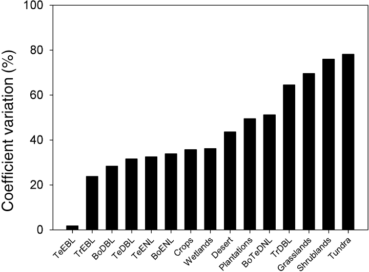

**Figure 2**

Open in figure viewer[PowerPoint](https://onlinelibrary.wiley.com/action/downloadFigures?id=f2&doi=10.1046%2Fj.1466-822X.2003.00026.x)

Coefficients of variation of LAI by biome following IQR outlier analysis (see Appendix 2 for key to acronyms).

### LAI collections by methodology

LAI values for the entire database were separated into groups by methodology (Fig. 3). Although the litterfall method tended to produce the highest mean (± SD) values (4.5 ± 2.0) and the allometry method produced the lowest (3.3 ± 2.1), none of the LAI groupings were statistically different. The indirect methods, such as from the LAI‐2000) canopy analyser (Welles & Norman, 1991), had a group mean (± SD) of 3.8 ± 1.9 and was statistically closest in value to LAI measurements collected via destructive harvests (3.5 ± 2.4).

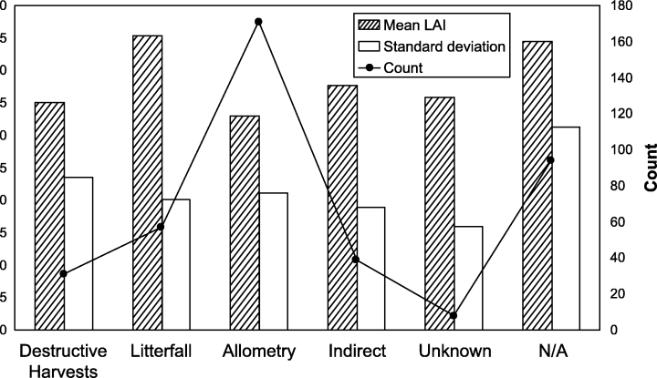

**Figure 3**

Open in figure viewer[PowerPoint](https://onlinelibrary.wiley.com/action/downloadFigures?id=f3&doi=10.1046%2Fj.1466-822X.2003.00026.x)

Statistics of LAI database organized by measurement methodology.

Given that indirect methods are significantly easier to collect, they can be applied to many studies over very large geographical areas (e.g. Asner *et al*., 2002). Destructive harvests (and litterfall) methods are extremely labour intensive and logistically expensive in comparison to the indirect approaches. This perspective continues to promote an increasing use of indirect measurement approaches in field studies. However, it is important to note that the indirect methods appear to perform more accurately in broadleaf canopies of horizontally continuous cover, while they underestimate LAI in needleleaf canopies (e.g. Chen & Cihlar, 1995), forest canopies with significant foliar clumping (e.g. Herbert & Fownes, 1997), and in canopies comprised of discrete crowns (e.g. White *et al*., 2000). In these cases, destructive harvests and other direct methods can be used to correct measurements acquired by indirect methods (e.g. Asner *et al*., 1998b).

### LAI collections over time

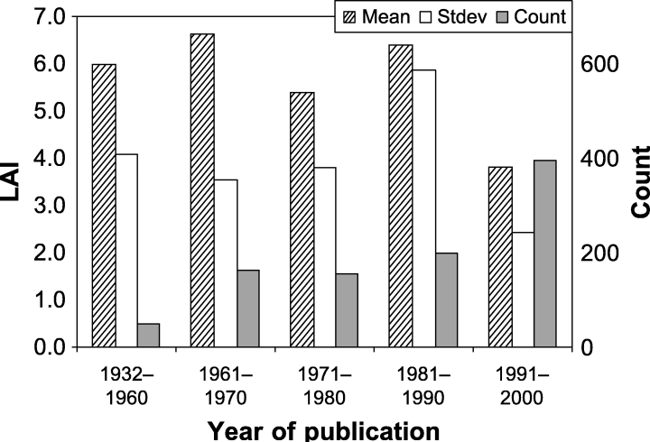

**Figure 4**

Open in figure viewer[PowerPoint](https://onlinelibrary.wiley.com/action/downloadFigures?id=f4&doi=10.1046%2Fj.1466-822X.2003.00026.x)

Statistics of LAI database organized by year of publication.

The decline in mean LAI in the 1990s may reflect the tendency towards indirect methodologies, which can underestimate LAI for some types of canopy (see last section). This decrease may also result from a noticeable decline in studies using direct measurement and allometry approaches in the database; these methods are often thought to contain small methodological errors that result in significant overestimation of LAI (Chen & Cihlar, 1995; Gower *et al*., 1999).

### Sample applications of LAI database

There are many possible uses for this LAI database. Ecological applications range from input to and validation of ecosystem and biogeochemical models to the prediction of LAI values for field studies in a particular biome or geographical region (e.g. Running & Gower, 1991; Schimel, 1995; Asner *et al*., 1998a). Other Earth science applications span a wide range of climate, hydrological, and energy balance studies (e.g. Yang *et al*., 1997; Kergoat, 1998; Lacaze *et al*., 1999). In support of these applications, many remote sensing approaches have been developed to estimate LAI at spatial scales ranging from plot (< 10 m<sup>2</sup>) to large regions (> 100 km<sup>2</sup>) (e.g. Asrar *et al*., 1986; Verstraete & Pinty, 1991; Gobron *et al*., 1997). These efforts require calibration and evaluation information, and this LAI database could contribute in this way. In this section, we highlight some example uses of the database to emphasize its role across a wide range of these applications.

The total amount of foliage in canopies reflects both biological and environmental controls over plant growth. Vegetation productivity is partially controlled by the efficiency of light capture in canopies, and this assumption forms the basis of many ecological models (Field *et al*., 1995). The relationship between above‐ground net primary productivity (ANPP) and LAI was investigated with a subset of locations in the LAI database for which both parameters were available (excluding unlikely values of ANPP > 4000 g/m<sup>2</sup>/year; Schimel, 1995). A modest but significant correlation (*r*<sup>2</sup> = 0.33; *P* < 0.05) was found between these two ecological variables (Fig. 5). Other controls over ANPP — climate, nutrients, land‐use history, etc. — probably account for the remaining variance in the relationship. Nonetheless, this type of evaluation is statistically robust for only a relatively large data compilation such as provided here. Extension of this analysis could be achieved by considering the contributory effects of climate, soil type, land use and other intrabiome variables affecting the relationship between ANPP and LAI.

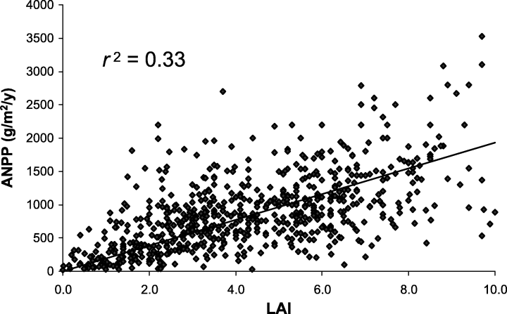

**Figure 5**

Open in figure viewer[PowerPoint](https://onlinelibrary.wiley.com/action/downloadFigures?id=f5&doi=10.1046%2Fj.1466-822X.2003.00026.x)

LAI vs. above‐ground net primary production (ANPP). LAI values are for all sites corresponding to ANPP field sites provided by Scurlock *et al*. (1996).

[figure not shown]

**Figure 6**

Open in figure viewer[PowerPoint](https://onlinelibrary.wiley.com/action/downloadFigures?id=f6&doi=10.1046%2Fj.1466-822X.2003.00026.x)

A likely use for the database is in validating LAI estimates derived from airborne and spaceborne remote sensing observations. Remote sensing does not directly measure LAI or any biophysical property of plant canopies; observations of the radiation reflected by vegetation are converted to estimates of biophysical variables using field studies or models (e.g. Myneni *et al*., 1997). Evaluation of remotely sensed LAI (or any other surface variable) is challenged by the inherent differences in the spatial scale of the field and remote measurements. New methodologies are still needed to employ field LAI measurements at spatial scales commensurate with remote sensing studies (e.g. Atkinson *et al*., 2000). Nonetheless, to demonstrate the potential use of the database, we compared field LAI observations to estimates derived from a combination of the NASA SeaWIFS sensor and the Myneni *et al*. (1997) LAI algorithm (in use now with NASA MODIS satellite data).

The SeaWIFS product was acquired from the MODIS LAI website (http://www.cybele.bu.edu/modismisr/product/seawifs/seqwifslaifpar.html) as quarterly mean LAI maps at 8 km spatial resolution with global coverage. The quarterly data were then averaged to produce a digital map of mean annual LAI (Fig. 7). Simply plotting the LAI values from the database against the colocated SeaWIFS‐LAI values yielded a regression with *r*<sup>2</sup> = 0.12 (data not shown). However, using the mean LAI value from the database (for biomes matching those available from the SeaWIFS algorithm) resulted in a significant correlation with the biome‐averaged LAI values derived from SeaWIFS (*r*<sup>2</sup> = 0.87, *P* < 0.05; Fig. 8). This basic validation approach is useful for determining the overall accuracy of the SeaWIFS LAI product, but additional studies are needed to evaluate the sensor/algorithm performance on a site, biome, or regional basis. Our example serves only to highlight this issue and call for improved scaling approaches for field‐to‐sensor validation efforts.

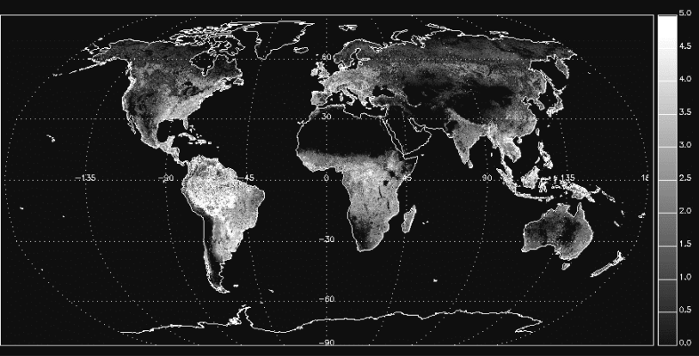

**Figure 7**

Open in figure viewer[PowerPoint](https://onlinelibrary.wiley.com/action/downloadFigures?id=f7&doi=10.1046%2Fj.1466-822X.2003.00026.x)

Global mean annual LAI derived from the NASA SeaWIFS sensor and the Myneni *et al*. (1997) canopy radiative transfer model.

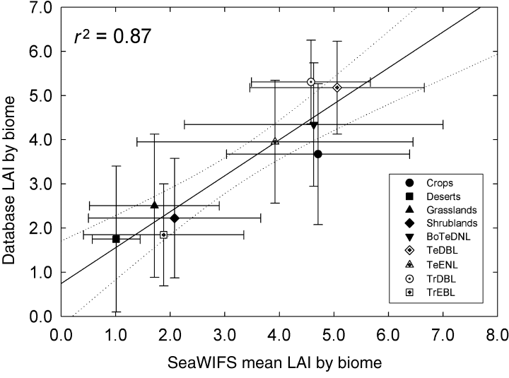

**Figure 8**

Open in figure viewer[PowerPoint](https://onlinelibrary.wiley.com/action/downloadFigures?id=f8&doi=10.1046%2Fj.1466-822X.2003.00026.x)

Mean LAI derived from SeaWIFS (Fig. 7) and from the LAI database. Error bars show standard deviation of the mean for each biome (see Appendix 2 for key to acronyms).

### Additional issues and caveats

As mentioned, despite our effort to produce a comprehensive LAI database, the values represented in this compilation are weighted more heavily on certain biomes and less so on others (Table 2). There are also biases toward certain geographical regions (countries) and plant genera (Table 3). Additional caveats and issues related to the use and interpretation of the data within this compilation should be mentioned here.

In developing the database, we found that LAI in needleleaf canopies stood out from other vegetation cover types in terms of maximum values (Table 2). An exception was the crops biome, for which LAI values were sometimes also reported as very high. Some of the needleleaf biomes included measurements of all‐sided LAI, which is clearly a different parameter from one‐sided broadleaf LAI. Older estimates of needleleaf LAI obtained using allometric equations tend to be biased by the larger, open‐grown trees used to develop the relationships between foliage mass and tree diameter (R. Waring, personal communication). Indirect LAI estimates (e.g. Licor LAI‐2000) are comparable with destructive harvesting or allometry for broadleaf canopies, but in needleleaf canopies it appears that a ‘clumping factor’ must also be taken into account (Chen *et al*., 1997). Such techniques estimate an ‘effective’ LAI, which may be an underestimate when foliage in the canopy is nonrandomly distributed or clumped (Gower *et al*., 1999).

The vast majority of these field‐based LAI data are from small sample plots, often 0.2 ha in size or less, but many studies do not clearly report the number of samples or their spatial extent. Such data represent the LAI of individual canopies or canopy clusters. However, as the integrated area of the measurements increases, the reported LAI decreases because the fractional cover of the canopies becomes a contributing factor:

LAI<sub>grid‐cell</sub> = LAI<sub>plant</sub> * f<sub>c</sub>

(3)

where LAI<sub>plant</sub> is the leaf area index of the individual canopy or canopy cluster, and f<sub>c</sub> is the fractional area covered by that canopy or cluster.

A small number of field studies have worked along homogenous transects, but very few studies have actually addressed the issue of extending field‐based LAI measurements to scales commensurate with regional and global modelling or remote sensing studies. However, the Bigfoot initiative (http://www.fsl.orst.edu/larse/bigfoot/) is addressing the topic of scaling from point field measurements to the relatively coarse resolution of satellite products, by measuring LAI and other land‐surface parameters for 5 × 5 km grids in the United States.

## CONCLUSIONS

In this paper, we present the most comprehensive database to date of leaf area index (LAI) measurements collected throughout the world. The LAI database includes more than 1000 samples collected in 15 biomes (or land‐cover types) spanning arid, semiarid, temperate, tropical, boreal and human‐managed ecosystems. The global extent of the database provides a means to test ecological, biogeochemical and physical models, to evaluate remote sensing studies, and to compare data from forthcoming field studies to previous work and across biomes. Here we presented the LAI database, carried out a statistical analysis of its contents, and provided some examples of how the database can be used in a variety of applications. The database is now available from the Oak Ridge National Laboratory (http://www.daac.ornl.gov) by referring to Technical Memorandum ORNL/TM‐2001/268 (Scurlock *et al*., 2001).

While our effort to compile a global LAI dataset was intended to be comprehensive, we cannot assert that it is complete, given the availability of additional measurements often embedded in studies covering a wide range of topics such as plant physiology, carbon and nutrient cycling, micrometeorology and faunal ecology. As such we recognize the limitations of the database, and acknowledge that some biomes — deserts, wetlands and shrublands in particular — are under‐represented here (Table 2). However, we also note that the coefficients of variation (CV) did not differ systematically by sample size (Fig. 2), and thus our findings and conclusions are not specifically driven by these shortcomings in sample size for certain biomes.

The conclusions of this paper are drawn from an initial analysis of the LAI data compilation and include:

- •

  Biomes with LAI values that are well represented in the literature include croplands, forests and plantations. Biomes that are not well represented are deserts, shrublands, tundra and wetlands. Additional measurements are needed from these biomes, particularly considering their high spatial and temporal variability of plant productivity, vegetation cover, and biomass.
- •

  Mean LAI values for all biomes did not differ statistically by the methodology employed. Direct and indirect measurement approaches produced similar results. However, the accuracy of each method varies by vegetation type (architecture) and landscape structure.
- •

  Mean LAI values for all biomes combined decreased significantly in the 1990s, a period of substantially more studies and use of indirect measurement approaches.
- •

  The potential applications of this LAI database span a wide range of ecological, biogeochemical, physical, and climate research areas. The data can be used as input to or validation of terrestrial ecosystem and land‐surface models, for evaluation of remotely sensed LAI estimates, for comparisons to forthcoming field studies, and in a variety of other applications.

## DATA AVAILABILITY

The LAI database is maintained and distributed by ORNL Distributed Active Archive Center (DAAC) for Biogeochemical Dynamics (http://www.daac.ornl.gov). The DAAC provides information about the Earth's biogeochemical dynamics to the global‐change research community, policymakers, educators, and the interested general public. The ORNL DAAC is part of the Earth Observing System Data and Information System Project of the National Aeronautics and Space Administration (NASA), which forms an integral part of NASA's contribution to the U.S. Global Change Research Program.

## ACKNOWLEDGMENTS

We thank S.T. Gower and R. Myneni for contributing to the LAI database, R. Myneni for use of the MODIS canopy radiative transfer model, and two anonymous reviewers of the manuscript. We thank V. Morris for assisting with the statistical analyses and B. Braswell for providing helpful comments on the manuscript. We thank R. Olson for helping with Fig. 1 and for guidance in developing the manuscript. This work was supported by NASA New Investigator Program (NIP) grant NAG5‐8709 and the NASA Terrestrial Ecology Program (TE/99–0005) under Interagency Agreement number 2013‐M164‐A1 with the U.S. Department of Energy.

## Appendix

Table APPENDIX1. List of column headings in the ORNL leaf area index database.

| Variable | Definition |
| --- | --- |
| Sitename | Unique common name for study site, where reported |
| Country | Country of study |
| Latitude | — |
| Longitude | — |
| LAI | Leaf area index, as reported (m<sup>2</sup>/m<sup>2</sup> or dimensionless) |
| Time of Measurement | Season, month, occasionally exact date |
| Year_LAI | Year of original study, where reported (otherwise assumed to be equal to Year of publication) |
| Methodology/remarks | Methodologies: |
|  | A — Destructive harvest |
|  | B — Litterfall |
|  | C — Allometry |
|  | D — Point quadrat/plumb line |
|  | E — Indirect noncontact (LAI‐2000 or other) |
|  | X — Unknown |
| Biome | Biome/land‐cover type, as reported |
| Biome cover | Biome/land‐cover type assigned to one of 15 classes (see Appendix 2) |
| Dominant species | Major species/genus/family, where reported |
| Author | Name of first author of original reference |
| Year pub | Year of publication |
| ANPP | Above‐ground net primary productivity (g/m<sup>2</sup>/year dry matter) |
| BNPP | Below‐ground net primary productivity (g/m<sup>2</sup>/year dry matter) |
| TNPP | Total net primary productivity (ANPP + BNPP) (g/m<sup>2</sup>/year dry matter) |
| Elevation | Elevation of study site in meters, as reported |
| Age | Age of vegetation stand in years (mostly reported for forests) |
| Remarks/original source | Additional remarks about peculiarities of the study; references to previous or related studies |

Table APPENDIX2. Biome/land‐cover classes based upon the Ecosystem Model‐Data Intercomparison (Olson *et al*., 2001), and acronyms that appear in the ORNL leaf area index database.

| Biome/land cover | Acronym or terminology used |
| --- | --- |
| Crops (temperate and tropical) | Crops |
| Deserts | Desert |
| Grasslands (temperate and tropical) | Grassland |
| Plantations (managed forests of temperate deciduous broadleaf, temperate evergreen needleleaf and tropical deciduous broadleaf lifeforms and species) | Plantation |
| Shrublands (heath or Mediterranean) | Shrubland |
| Tundra (circumpolar and alpine) | Tundra |
| Wetlands, temperate and tropical | Wetland |
| Forest, boreal deciduous broadleaf | BoDBL |
| Forest, boreal evergreen needleleaf | BoENL |
| Forest, boreal/temperate deciduous needleleaf | BoTeDNL |
| Forest, temperate deciduous broadleaf | TeDBL |
| Forest, temperate evergreen needleleaf | TeENL |
| Forest, temperate evergreen broadleaf | TeEBL |
| Forest, tropical deciduous broadleaf | TrDBL |
| Forest, tropical evergreen broadleaf | TrEBL |

[output not shown]

## Citing Literature

[figure not shown]

[Volume12, Issue3](https://onlinelibrary.wiley.com/toc/14668238/2003/12/3)

May 2003

Pages 191-205

### Metrics

- Citations: 430

### Keywords

  - [canopy structure](https://onlinelibrary.wiley.com/action/doSearch?field1=Keyword&text1=canopy%20structure)
  - [ecosystem modelling](https://onlinelibrary.wiley.com/action/doSearch?field1=Keyword&text1=ecosystem%20modelling)
  - [global ecology](https://onlinelibrary.wiley.com/action/doSearch?field1=Keyword&text1=global%20ecology)
  - LAI
  - [leaf area index](https://onlinelibrary.wiley.com/action/doSearch?field1=Keyword&text1=leaf%20area%20index)
  - [remote sensing](https://onlinelibrary.wiley.com/action/doSearch?field1=Keyword&text1=remote%20sensing)

### Publication History

  - Issue Online: 11 April 2003
  - Version of Record online: 11 April 2003

[Download PDF](https://onlinelibrary.wiley.com/doi/pdf/10.1046/j.1466-822X.2003.00026.x)

back